# DEM 5283/7283 Week 3: Binary Outcomes with Logit and Probit Models

Statistics for Demographic Data II

Author

Corey S. Sparks, PhD

Published

October 22, 2026

## Introduction

Most of the outcomes demographers care about aren’t continuous. Someone migrates or doesn’t, has a birth this year or doesn’t, dies before age 65 or doesn’t, reports poor health or doesn’t. Transitions (from employed to unemployed, from married to divorced) and thresholds (being obese, being in poverty) usually end up coded the same way, as a 1 or a 0. This week is about the workhorse models for those outcomes, the logit and the probit, fit to complex survey data.

The models themselves are not hard to fit. The hard part, and the part I want you to spend your time on, is saying what the results mean. Logit coefficients are changes in log-odds, which nobody thinks in. Odds ratios are better, but they are routinely misread as risk ratios. So most of this document is about turning model output into predicted probabilities and average marginal effects, the quantities you should report in your papers (Mood 2010; Breen et al. 2018).

## Setup

`marginaleffects` does the post-estimation work. It handles predicted probabilities, comparisons and marginal effects for almost any model in R, including `svyglm()`.

```r
library(tidyverse)
library(here)
library(survey)
library(marginaleffects)
library(modelsummary)
library(gtsummary)
library(sparkscolors)

source(here("R", "get_mmsa.R"))
source(here("R", "recode_mmsa.R"))
```

## Generalized linear models for binary outcomes

### From the linear model to the GLM

Up to now you’ve mostly relied on linear models that assume a Normal distribution for the outcome. A broader class, **generalized linear models** or GLMs (Nelder and Wedderburn 1972), allows regression for outcomes that aren’t Normal. Every GLM has three parts: a probability distribution suited to the outcome, a **linear predictor** made of the coefficients and covariates, and a **link function** that connects the mean of the distribution to the linear predictor. The linear model is a GLM, too. Its mean is $\mu$, and the linear predictor is connected to it directly:

$$g(\mu) = g(E(Y)) = \beta_0 + \beta_1 x_1, \qquad g(\mu) = \mu$$

That’s the **identity link**: no transformation at all. It works for the Normal because the Normal can take any value from $-\infty$ to $\infty$, so a straight line can’t wander off the scale of the data. Other distributions have narrower ranges, and their links transform the mean so the linear predictor stays on the right scale.

For a binary outcome, the distribution is the binomial, which you’ve probably met in a basic statistics course (remember the coin flips?). It gets used in two ways. When each person has a single “trial,” with an outcome of 1 or 0, it’s called the **Bernoulli** distribution, and that’s the logistic regression you’ve probably seen before. When we have $y$ events out of $n$ trials, which is the basic makeup of a demographic rate (deaths out of people at risk, low birth weight births out of all births), we have what I call the **count-based binomial**. Either way the mean is a probability, $\pi$, and the model is

$$\Pr(y = 1) = \frac{y}{n} = \pi = \text{some function of the predictors}$$

This week is about the Bernoulli case, with individual survey respondents. We’ll use the count-based binomial for rates in places in week 6.

### Why not the linear model?

If $y_i$ is 1 or 0, its mean is a probability, $\pi_i = P(y_i = 1)$, and its variance is $\pi_i(1 - \pi_i)$. A linear model for $\pi_i$ (the **linear probability model**) has two problems. The variance depends on the mean, so the errors can’t be homoskedastic, and nothing stops the fitted values from going below 0 or above 1. The linear probability model has defenders, mostly in economics, and I’ll come back to it at the end, because its coefficients are often close to the average marginal effects from a logit. But for most demographic work we want a model that respects the bounds.

### Link functions

A **generalized linear model** (GLM) keeps the linear predictor, $\eta_i = \mathbf{x}_i'\boldsymbol\beta$, and connects it to the mean through a **link function** $g()$, so that $g(\pi_i) = \eta_i$. The link stretches the interval from 0 to 1 onto the whole real line. The **logit** link is the log of the odds:

$$\text{logit}(\pi_i) = \log\left(\frac{\pi_i}{1 - \pi_i}\right) = \mathbf{x}_i'\boldsymbol\beta
\quad\Longleftrightarrow\quad
\pi_i = \frac{1}{1 + \exp(-\mathbf{x}_i'\boldsymbol\beta)}$$

It’s worth walking through that one step at a time. The **odds** of an event are the probability it happens divided by the probability it doesn’t, $\pi / (1 - \pi)$. A probability is stuck between 0 and 1, but the odds run from 0 to $\infty$, and taking the log of the odds stretches that onto the whole real line, from $-\infty$ to $\infty$. Now a linear function of the covariates can’t go out of bounds, and we can write the model as $\text{logit}(\pi) = \beta_0 + \beta_1 x_1$ without worrying about the boundary problem.

The **probit** link is the inverse of the standard normal cumulative distribution function, $\Phi^{-1}(\pi_i) = \mathbf{x}_i'\boldsymbol\beta$, so $\pi_i = \Phi(\mathbf{x}_i'\boldsymbol\beta)$. A third link, the **complementary log-log**, $\log(-\log(1 - \pi_i)) = \mathbf{x}_i'\boldsymbol\beta$, is asymmetric, and it comes up mostly when the binary outcome is really whether an event happened in an interval of time, which is why you’ll see it again in your event history course.

Both models can also be written as models for a latent propensity $y_i^* = \mathbf{x}_i'\boldsymbol\beta + \varepsilon_i$, where we only see $y_i = 1$ when $y_i^* > 0$. The logit assumes $\varepsilon$ has a logistic distribution (variance $\pi^2/3$), and the probit assumes a standard normal (variance 1). That’s the whole difference between them, and it’s why logit coefficients are about 1.6 to 1.8 times the size of probit coefficients for the same data. It’s also the source of the nested model problem we’ll take on in week 4.

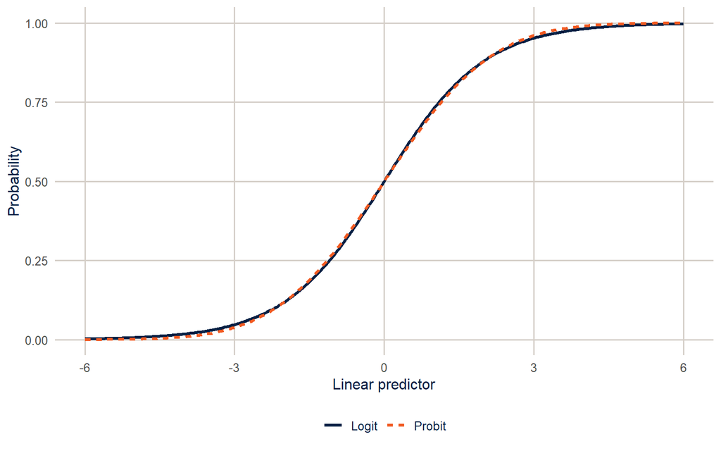

Figure 1: The logit and probit curves map the linear predictor onto a probability. The probit is drawn with its predictor scaled by 1.7 so the two are comparable.

```r
tibble(eta = seq(-6, 6, by = 0.05)) |>
  mutate(Logit = plogis(eta),
         Probit = pnorm(eta / 1.7)) |>
  pivot_longer(-eta, names_to = "link", values_to = "probability") |>
  ggplot(aes(x = eta, y = probability, colour = link, linetype = link)) +
  geom_line(linewidth = 1.2) +
  scale_colour_utsa(palette = "primary") +
  labs(x = "Linear predictor", y = "Probability", colour = NULL, linetype = NULL)
```

### Odds and odds ratios

Because we modeled the log of the odds, the coefficients are on the log-odds scale, not a linear one. We can read their signs directly (a positive $\beta$ raises the odds of $y = 1$, a negative one lowers them), but the usual interpretation is the **odds ratio**, which you get by exponentiating the coefficient. The percent change in the odds for a one-unit change in $x_1$ is

$$\%\Delta \text{ odds} = 100 \times \left(\exp(\beta_1) - 1\right)$$

So a $\beta_1$ of 0.025 gives $\exp(0.025) = 1.025$, and a one-unit increase in $x_1$ raises the odds of $y$ by 2.5%. If $\beta_1 = 0.4$, then $\exp(0.4) = 1.49$, a 49% increase in the odds. A negative coefficient works the same way: $\beta_1 = -0.15$ gives $\exp(-0.15) - 1 = -0.14$, a 14% decrease. Odds ratios are constant across the range of $x$, which is convenient, but odds are not probabilities, and that difference will come back below.

## The data and some descriptive work

The outcome is fair or poor self-rated health in the 2024 BRFSS SMART MMSA file. Self-rated health is one of the best single predictors of mortality we have, and it’s asked in almost every health survey, which makes it a good teaching outcome. `recode_mmsa()` makes the variables from week 2.

```r
brfss <- get_mmsa(2024) |> recode_mmsa()
des <- svydesign(ids = ~1, strata = ~ststr, weights = ~mmsawt, data = brfss)
```

Before any model, look at the outcome by the main predictors. `svyciprop()` gives design-based confidence intervals for proportions.

```r
desc <- c("educ", "race_eth") |>
  set_names() |>
  map(\(v) {
    res <- svyby(~badhealth, reformulate(v), design = des, FUN = svyciprop,
                 vartype = "ci", na.rm = TRUE)
    tibble(group = as.character(res[[v]]), estimate = coef(res),
           ci_l = res$ci_l, ci_u = res$ci_u)
  }) |>
  list_rbind(names_to = "variable") |>
  mutate(variable = if_else(variable == "educ", "Education", "Race and ethnicity"),
         group = fct_inorder(group))

svychisq(~badhealth + educ, design = des)
```

```
    Pearson's X^2: Rao & Scott adjustment

data:  svychisq(~badhealth + educ, design = des)
F = 775.81, ndf = 2.7835e+00, ddf = 6.3863e+05, p-value < 2.2e-16
```

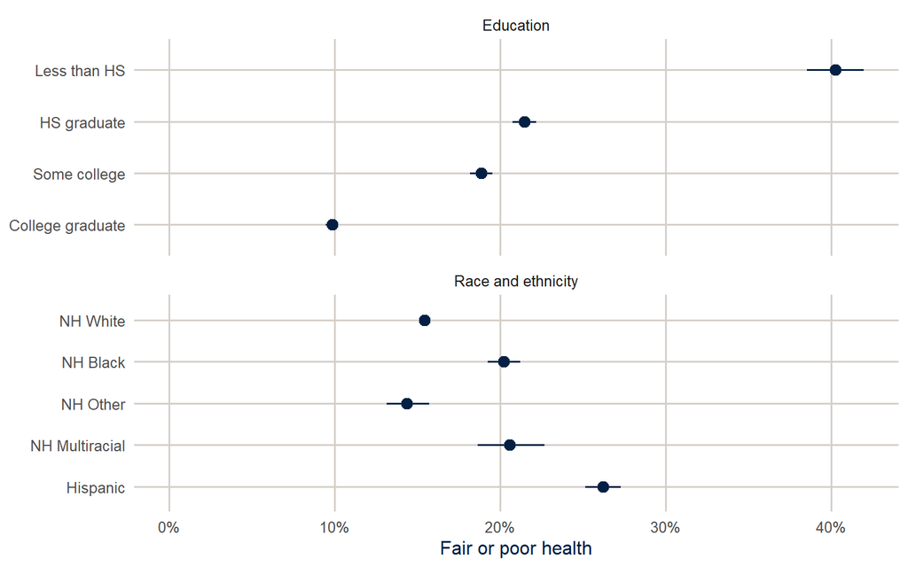

Figure 2: Share of adults reporting fair or poor health, with 95% confidence intervals, 2024 BRFSS SMART MMSA.

```r
desc |>
  ggplot(aes(x = estimate, y = fct_rev(group))) +
  geom_pointrange(aes(xmin = ci_l, xmax = ci_u), colour = utsa_cols("midnight")) +
  facet_wrap(~variable, scales = "free_y", ncol = 1) +
  scale_x_continuous(labels = scales::label_percent(), limits = c(0, NA)) +
  labs(x = "Fair or poor health", y = NULL)
```

The education gradient is steep, and Hispanic adults report fair or poor health at a higher rate than any other group. Part of that is education, and part may be about how the question works across languages and cultures (a long-standing debate in the Hispanic health literature). The model below starts to separate the first part out.

Before the model, though, it’s worth looking at the two variables together. `svyby()` with two grouping variables gives the prevalence for every combination of race and ethnicity and education.

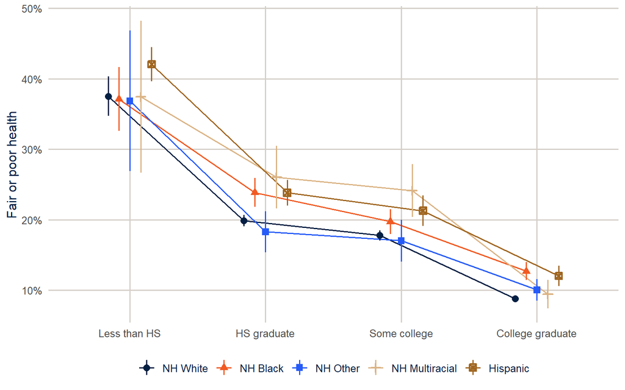

Figure 3: Share of adults reporting fair or poor health by race and ethnicity and education, with 95% confidence intervals.

```r
race_educ <- svyby(~badhealth, ~race_eth + educ, design = des, FUN = svymean,
                   na.rm = TRUE)

race_educ |>
  as_tibble() |>
  mutate(ci_l = badhealth - 1.96 * se, ci_u = badhealth + 1.96 * se) |>
  ggplot(aes(x = educ, y = badhealth, colour = race_eth, shape = race_eth,
             group = race_eth)) +
  geom_line(position = position_dodge(width = 0.4)) +
  geom_pointrange(aes(ymin = ci_l, ymax = ci_u), position = position_dodge(width = 0.4)) +
  scale_colour_utsa() +
  scale_y_continuous(labels = scales::label_percent()) +
  labs(x = NULL, y = "Fair or poor health", colour = NULL, shape = NULL)
```

The education gradient shows up in every group, and within each level of education the racial and ethnic differences are much smaller than they were overall. The overall Hispanic-White gap is more than 10 percentage points, and within education groups it’s closer to 3 to 5. That’s the descriptive version of what the model will tell us: some, but not all, of the Hispanic disadvantage is about education.

## Fitting logit and probit models

Logit and probit models for survey data are just `svyglm()` with a binomial family. I use `quasibinomial()`, which gives exactly the same estimates as `binomial()` but doesn’t warn about non-integer weights.

```r
fit_logit <- svyglm(badhealth ~ race_eth + educ + agec + female,
                    design = des, family = quasibinomial())

fit_probit <- svyglm(badhealth ~ race_eth + educ + agec + female,
                     design = des, family = quasibinomial(link = "probit"))

summary(fit_logit)
```

```
Call:
svyglm(formula = badhealth ~ race_eth + educ + agec + female,
    design = des, family = quasibinomial())

Survey design:
svydesign(ids = ~1, strata = ~ststr, weights = ~mmsawt, data = brfss)

Coefficients:
                       Estimate Std. Error t value Pr(>|t|)
(Intercept)            -1.41064    0.06110 -23.087  < 2e-16 ***
race_ethNH Black        0.26653    0.03571   7.464 8.39e-14 ***
race_ethNH Other        0.17266    0.05792   2.981  0.00287 **
race_ethNH Multiracial  0.46511    0.06606   7.041 1.91e-12 ***
race_ethHispanic        0.42880    0.03609  11.883  < 2e-16 ***
educHS graduate        -0.72464    0.04490 -16.139  < 2e-16 ***
educSome college       -0.94626    0.04620 -20.480  < 2e-16 ***
educCollege graduate   -1.68825    0.04551 -37.098  < 2e-16 ***
agec25-34               0.27387    0.05648   4.849 1.24e-06 ***
agec35-44               0.44910    0.05493   8.176 2.95e-16 ***
agec45-54               0.77399    0.05405  14.320  < 2e-16 ***
agec55-64               0.97025    0.05155  18.823  < 2e-16 ***
agec65+                 1.07579    0.04921  21.860  < 2e-16 ***
female                  0.09881    0.02519   3.922 8.78e-05 ***
---
Signif. codes:  0 '***' 0.001 '**' 0.01 '*' 0.05 '.' 0.1 ' ' 1

(Dispersion parameter for quasibinomial family taken to be 1.002631)

Number of Fisher Scoring iterations: 4
```

The coefficients are on the log-odds scale. Positive values mean higher odds of fair or poor health, so everything here goes in the direction the descriptive figures suggested. To test whether a whole set of dummies matters, use a design-based Wald test (likelihood ratio tests aren’t valid with survey weights):

```r
regTermTest(fit_logit, ~race_eth, method = "Wald")
```

```
Wald test for race_eth
 in svyglm(formula = badhealth ~ race_eth + educ + agec + female,
    design = des, family = quasibinomial())
F =  48.73079  on  4  and  223010  df: p= < 2.22e-16
```

Here are the odds ratios next to the probit coefficients:

```r
modelsummary(list("Logit (odds ratios)" = fit_logit, "Probit" = fit_probit),
             exponentiate = c(TRUE, FALSE),
             fmt = 3,
             coef_omit = "Intercept",
             coef_rename = \(x) str_remove_all(x, "race_eth|educ|agec"),
             gof_map = "nobs",
             title = "Models for fair or poor self-rated health")
```

Table 1

Models for fair or poor self-rated health

|  | Logit (odds ratios) | Probit |
| --- | --- | --- |
| NH Black | 1.305 | 0.150 |
|  | (0.047) | (0.020) |
| NH Other | 1.188 | 0.097 |
|  | (0.069) | (0.032) |
| NH Multiracial | 1.592 | 0.253 |
|  | (0.105) | (0.037) |
| Hispanic | 1.535 | 0.241 |
|  | (0.055) | (0.021) |
| HS graduate | 0.485 | -0.441 |
|  | (0.022) | (0.027) |
| Some college | 0.388 | -0.564 |
|  | (0.018) | (0.028) |
| College graduate | 0.185 | -0.968 |
|  | (0.008) | (0.027) |
| 25-34 | 1.315 | 0.157 |
|  | (0.074) | (0.030) |
| 35-44 | 1.567 | 0.250 |
|  | (0.086) | (0.029) |
| 45-54 | 2.168 | 0.425 |
|  | (0.117) | (0.029) |
| 55-64 | 2.639 | 0.536 |
|  | (0.136) | (0.028) |
| 65+ | 2.932 | 0.602 |
|  | (0.144) | (0.026) |
| female | 1.104 | 0.057 |
|  | (0.028) | (0.014) |
| Num.Obs. | 224220 | 224220 |

College graduates have 0.18 times the odds of fair or poor health of adults without a high school diploma, so their odds are 82% lower. Hispanic adults have 1.54 times the odds of non-Hispanic White adults with the same education, age and sex. The ratio of logit to probit coefficients runs from about 1.7 to 1.8 for most terms, so the two models say the same thing in different units. Both show higher chances of fair or poor health for every group compared with non-Hispanic White adults (the reference group), most of all for Hispanic and multiracial adults, a steady decline with each step up in education compared with not finishing high school, and a steady rise with age compared with adults under 25. If you do report odds ratios, report them with confidence intervals. `tbl_regression()` from `gtsummary` exponentiates the coefficients, computes design-based intervals, and lays out the reference groups clearly:

```r
tbl_regression(fit_logit, exponentiate = TRUE,
               label = list(race_eth ~ "Race and ethnicity", educ ~ "Education",
                            agec ~ "Age group", female ~ "Female")) |>
  bold_labels()
```

Table 2

| **Characteristic** | **OR** | **95% CI** | **p-value** |
| --- | --- | --- | --- |
| Race and ethnicity |  |  |  |
| NH White | — | — |  |
| NH Black | 1.31 | 1.22, 1.40 | <0.001 |
| NH Other | 1.19 | 1.06, 1.33 | 0.003 |
| NH Multiracial | 1.59 | 1.40, 1.81 | <0.001 |
| Hispanic | 1.54 | 1.43, 1.65 | <0.001 |
| Education |  |  |  |
| Less than HS | — | — |  |
| HS graduate | 0.48 | 0.44, 0.53 | <0.001 |
| Some college | 0.39 | 0.35, 0.42 | <0.001 |
| College graduate | 0.18 | 0.17, 0.20 | <0.001 |
| Age group |  |  |  |
| 18-24 | — | — |  |
| 25-34 | 1.32 | 1.18, 1.47 | <0.001 |
| 35-44 | 1.57 | 1.41, 1.75 | <0.001 |
| 45-54 | 2.17 | 1.95, 2.41 | <0.001 |
| 55-64 | 2.64 | 2.39, 2.92 | <0.001 |
| 65+ | 2.93 | 2.66, 3.23 | <0.001 |
| Female | 1.10 | 1.05, 1.16 | <0.001 |

Abbreviations: CI = Confidence Interval, OR = Odds Ratio

A picture is often easier to digest. On the odds ratio scale, an interval that crosses 1 means the effect isn’t statistically different from zero. I put the axis on a log scale, because an odds ratio of 0.5 is as far from 1 as an odds ratio of 2.

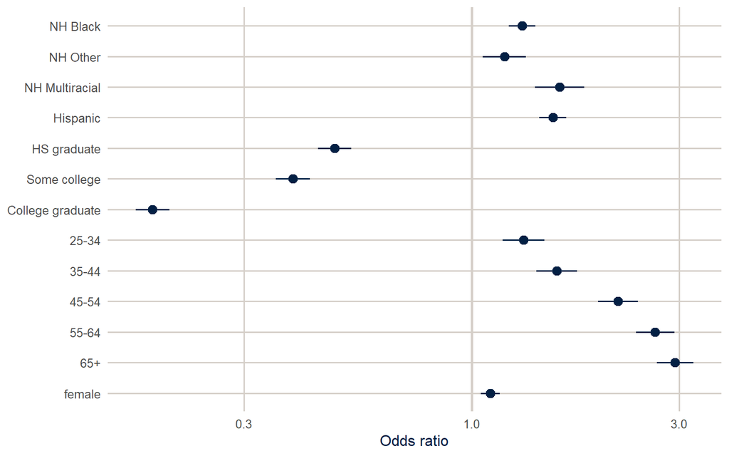

Figure 4: Odds ratios and 95% confidence intervals for fair or poor health. The axis is on a log scale.

```r
broom::tidy(fit_logit, conf.int = TRUE, exponentiate = TRUE) |>
  filter(term != "(Intercept)") |>
  mutate(term = str_remove_all(term, "race_eth|educ|agec"),
         term = fct_inorder(term)) |>
  ggplot(aes(x = estimate, y = fct_rev(term))) +
  geom_vline(xintercept = 1, colour = utsa_cols("smoke"), linewidth = 1) +
  geom_pointrange(aes(xmin = conf.low, xmax = conf.high), colour = utsa_cols("midnight")) +
  scale_x_log10() +
  labs(x = "Odds ratio", y = NULL)
```

## From coefficients to probabilities

### Predicted probabilities for particular people

As I often say, I like to talk about interesting cases. To do that, we need the fitted probability for a particular kind of person, and getting it just means “solving the equation” for the model at the values of $x$ that describe that person. For a non-Hispanic White woman age 45 to 54 with a college degree, everything but the intercept, the college dummy, the age dummy and the female dummy is zero, so

$$\Pr(\text{fair/poor health}) = \frac{1}{1 + \exp\left[-(\beta_0 + \beta_{\text{college}} + \beta_{45\text{-}54} + \beta_{\text{female}})\right]}$$

Here it is by hand:

```r
b <- coef(fit_logit)
eta <- b[["(Intercept)"]] + b[["educCollege graduate"]] + b[["agec45-54"]] + b[["female"]]
plogis(eta)   # plogis() is the inverse logit, 1 / (1 + exp(-eta))
```

```
[1] 0.09743142
```

Doing that for many kinds of people gets tedious, and it doesn’t give you a confidence interval. So what’s the predicted probability of fair or poor health for a 45-to-54-year-old woman, by race and ethnicity and education? `datagrid()` builds the “people,” and `predictions()` computes their probabilities with confidence intervals.

```r
cases <- predictions(fit_logit,
                     newdata = datagrid(race_eth = c("NH White", "NH Black", "Hispanic"),
                                        educ = c("HS graduate", "College graduate"),
                                        agec = "45-54",
                                        female = 1))

cases |>
  as_tibble() |>
  select(race_eth, educ, estimate, conf.low, conf.high) |>
  knitr::kable(digits = 3)
```

| race_eth | educ | estimate | conf.low | conf.high |
| --- | --- | --- | --- | --- |
| NH White | HS graduate | 0.221 | 0.207 | 0.234 |
| NH White | College graduate | 0.097 | 0.091 | 0.104 |
| NH Black | HS graduate | 0.270 | 0.251 | 0.289 |
| NH Black | College graduate | 0.124 | 0.113 | 0.134 |
| Hispanic | HS graduate | 0.303 | 0.283 | 0.323 |
| Hispanic | College graduate | 0.142 | 0.130 | 0.154 |

For a Hispanic woman in her late 40s with a high school diploma, the model predicts a 30.3% chance of reporting fair or poor health. For a non-Hispanic White woman with a college degree, it’s 9.7%, the same number we got by hand. Sentences like these are far easier for a reader to hold on to than “the odds ratio is 0.18.”

### Average predictions

Choosing interesting cases is a judgment call, and the results depend on what you hold the other variables at. **Average predictions** avoid the choice. For each level of education, set *everyone’s* education to that level, keep everything else as observed, predict, and average over the sample with the survey weights.

```r
avg_predictions(fit_logit, variables = "educ", wts = "(weights)")
```

```
             educ Estimate Std. Error    z Pr(>|z|)   S  2.5 % 97.5 %
 Less than HS        0.367    0.00867 42.3   <0.001 Inf 0.3499  0.384
 HS graduate         0.223    0.00372 59.9   <0.001 Inf 0.2156  0.230
 Some college        0.188    0.00350 53.6   <0.001 Inf 0.1808  0.194
 College graduate    0.100    0.00197 51.0   <0.001 Inf 0.0963  0.104

Type: response
```

This is the answer to the question “what share of adults would report fair or poor health if everyone had this level of education, and nothing else about them changed?” It’s a counterfactual quantity, and it’s what most people have in mind when they talk about “the effect of education” in a model like this.

### Average marginal effects

The **average marginal effect** (AME) of a categorical predictor is the difference between two of these average predictions. For a continuous predictor, it’s the average of the slope of the probability curve. Either way, it’s on the probability scale.

```r
ame_logit <- avg_comparisons(fit_logit, variables = c("race_eth", "educ"),
                             wts = "(weights)")
ame_logit
```

```
     Term                        Contrast Estimate Std. Error      z Pr(>|z|)
 educ     College graduate - Less than HS  -0.2667    0.00903 -29.55   <0.001
 educ     HS graduate - Less than HS       -0.1441    0.00955 -15.09   <0.001
 educ     Some college - Less than HS      -0.1793    0.00954 -18.79   <0.001
 race_eth Hispanic - NH White               0.0619    0.00559  11.07   <0.001
 race_eth NH Black - NH White               0.0368    0.00518   7.10   <0.001
 race_eth NH Multiracial - NH White         0.0678    0.01071   6.33   <0.001
 race_eth NH Other - NH White               0.0232    0.00812   2.86   0.0043
     S    2.5 %  97.5 %
 634.9 -0.28441 -0.2490
 168.4 -0.16277 -0.1253
 259.4 -0.19800 -0.1606
  92.2  0.05093  0.0728
  39.6  0.02661  0.0469
  31.9  0.04680  0.0888
   7.9  0.00726  0.0391

Type: response
```

A college degree, compared with not finishing high school, is associated with a 26.7 percentage point lower probability of fair or poor health, averaged over the population. Being Hispanic rather than non-Hispanic White is associated with a probability 6.2 points higher.

**Note**

You’ll also see **marginal effects at the mean** (MEMs), which compute the slope for a single made-up person with every variable at its mean. With categorical predictors, that person is a fraction Hispanic and a fraction college graduate, which describes nobody. AMEs average over real people instead, and they’re the better default (Mood 2010). If you want effects for a specific kind of person, use `datagrid()` and say so.

### Logit, probit, or a linear probability model?

Here are the AMEs for education and race from the logit, the probit, and a linear probability model (which is just `svyglm()` with a Gaussian family, so its coefficients *are* differences in probability).

```r
fit_lpm <- svyglm(badhealth ~ race_eth + educ + agec + female,
                  design = des, family = gaussian())

ame_all <- list(Logit = fit_logit, Probit = fit_probit, LPM = fit_lpm) |>
  map(\(m) avg_comparisons(m, variables = c("race_eth", "educ"), wts = "(weights)")) |>
  map(as_tibble) |>
  list_rbind(names_to = "model") |>
  mutate(model = fct_inorder(model),
         contrast = str_remove(contrast, " - .*$"),
         label = paste0(if_else(term == "educ", "Educ: ", "Race: "), contrast),
         label = factor(label, levels = c(paste0("Educ: ", levels(brfss$educ)[-1]),
                                          paste0("Race: ", levels(brfss$race_eth)[-1]))))
```

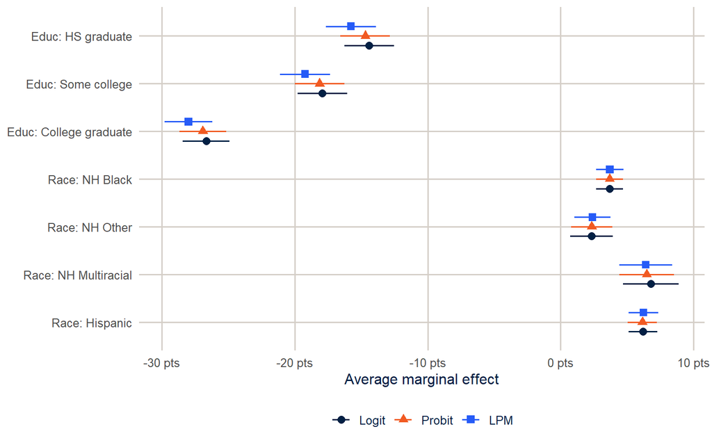

Figure 5: Average marginal effects on the probability of fair or poor health from logit, probit and linear probability models. Reference groups are non-Hispanic White and less than high school.

```r
ame_all |>
  ggplot(aes(x = estimate, y = fct_rev(label), colour = model, shape = model)) +
  geom_vline(xintercept = 0, colour = utsa_cols("smoke")) +
  geom_pointrange(aes(xmin = conf.low, xmax = conf.high),
                  position = position_dodge(width = 0.6)) +
  scale_colour_utsa() +
  scale_x_continuous(labels = scales::label_number(scale = 100, suffix = " pts")) +
  labs(x = "Average marginal effect", y = NULL, colour = NULL, shape = NULL)
```

The three models agree closely on the probability scale, which is the usual result when the outcome isn’t too rare and the predictors are mostly categorical. That’s the case for the linear probability model: easy to explain, and often the same answer. The case against it is that its individual predictions can fall outside 0 and 1, and its effects are forced to be the same for everyone, which matters when you care about how an effect differs across people with different baseline risks. My advice is to fit a logit or probit, report AMEs, and check that a linear probability model tells the same story.

```r
lpm_fitted <- predict(fit_lpm)
range(lpm_fitted)
```

```
[1] -0.01930623  0.49245739
```

```r
sum(lpm_fitted < 0)
```

```
[1] 2033
```

Here 2033 respondents get negative predicted probabilities. That’s harmless for the AMEs, but it’s a reminder that the linear probability model isn’t a model of individual probabilities.

## Odds ratios are not risk ratios

One last thing, because I see it in published papers all the time. An odds ratio of 2 does *not* mean the outcome is twice as likely. When the outcome is rare (under about 10%), odds and probabilities are close and so are odds ratios and risk ratios. When it’s common, the odds ratio is further from 1 than the risk ratio, sometimes by a lot. About 18% of adults report fair or poor health, so we’re in the zone where it matters.

`avg_comparisons()` with `comparison = "ratio"` computes the average risk ratio directly.

```r
rr <- avg_comparisons(fit_logit, variables = list(educ = c("Less than HS", "College graduate")),
                      comparison = "ratio", wts = "(weights)")
rr
```

```
 Estimate Std. Error    z Pr(>|z|)     S 2.5 % 97.5 %
    0.273    0.00868 31.4   <0.001 718.6 0.256   0.29

Term: educ
Type: response
Comparison: mean(College graduate) / mean(Less than HS)
```

The odds ratio for a college degree was 0.18, but the ratio of average predicted probabilities is 0.27. “College graduates are 73% less likely to report fair or poor health” is a correct sentence. “College graduates are 82% less likely” is not, even though you could read it straight off the odds ratio. If you report odds ratios, call them odds ratios, and give the probabilities too.

## Exercises

These exercises are Homework 3.

**1.** Fit a survey-weighted logit model for obesity (`obese`) with race and ethnicity, education, age group, sex and smoking status (`smoke`) as predictors. Report the odds ratios and the AMEs in one table or figure, and write two or three sentences interpreting the education results on the probability scale.

```r
# YOUR CODE HERE
```

**One way to start exercise 1**

```r
fit_ob <- svyglm(obese ~ race_eth + educ + agec + female + smoke,
                 design = des, family = quasibinomial())

modelsummary(fit_ob, exponentiate = TRUE, coef_omit = "Intercept")

avg_comparisons(fit_ob, variables = c("educ", "smoke"), wts = "(weights)")
```

**2.** Using the obesity model, compute predicted probabilities for three “interesting cases” of your choosing with `datagrid()`. Explain why you picked them.

```r
# YOUR CODE HERE
```

**3.** Add an interaction between education and sex to the fair or poor health model. Use `avg_predictions()` with `variables = c("educ", "female")` to show the predicted probabilities, and say whether the education gradient looks different for men and women. (Week 4 will show how to test this properly.)

```r
# YOUR CODE HERE
```

**4.** Compute the risk ratio and the odds ratio for current smoking (versus never smoking) from your obesity model. How far apart are they, and why?

```r
# YOUR CODE HERE
```

## References

Breen, Richard, Kristian Bernt Karlson, and Anders Holm. 2018. “Interpreting and Understanding Logits, Probits, and Other Nonlinear Probability Models.” *Annual Review of Sociology* 44: 39–54.

Mood, Carina. 2010. “Logistic Regression: Why We Cannot Do What We Think We Can Do, and What We Can Do about It.” *European Sociological Review* 26 (1): 67–82. https://doi.org/10.1093/esr/jcp006.

Nelder, J. A., and R. W. M. Wedderburn. 1972. “Generalized Linear Models.” *Journal of the Royal Statistical Society: Series A (General)* 135 (3): 370–84. https://doi.org/10.2307/2344614.